# 雙因子 ANOVA

Week 11 · Part 3

## 減重諮詢的差會隨冥想諮詢改變嗎？

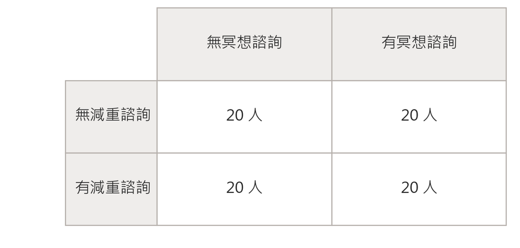

兩個因子組成 2 × 2 因子設計（factorial design），每格（cell）20 人。

- **分組**：假設將 80 位高血壓病人隨機分成四組。
- **兩個因子（factor）**：減重諮詢、冥想諮詢，各有「有／無」兩個水準（level）。
- **量測**：一個月後舒張壓（diastolic blood pressure, DBP）的下降量（mmHg）。

用**雙因子變異數分析（two-way ANOVA）**比較兩種冥想條件下的減重差。

Rosner 8e 第 12 章 Problems 12.14–12.17、Table 12.33，p. 622（書中假設情境）。

## 格平均怎麼變成邊際平均？

每格數字是**格平均（cell mean）**，單位為 mmHg。算出有、無減重諮詢各自的平均，再算有、無冥想諮詢各自的平均。

- 各格人數相同，因此直接平均兩格。得到的**邊際平均（marginal mean）**是減重 3.00、6.95，冥想 3.20、6.75。
- **主要效果（main effect）**比較某個因子的邊際平均。有減重諮詢平均多降 3.95 mmHg。這個 3.95 能代表兩種冥想條件下的情形嗎？

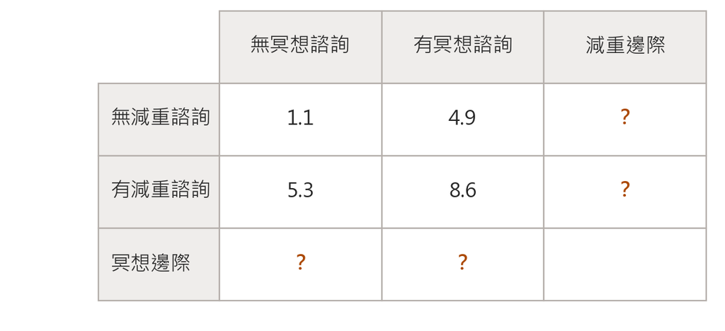

先填每列右端，再填每欄下端。

Rosner 8e Table 12.33。邊際平均依各格平均計算。

## 兩種冥想條件下，減重的差一樣嗎？

用表中的格平均，在兩種冥想條件下各算一次 **有減重 − 無減重**。兩個差相同嗎？

- 無冥想諮詢是 $5.3-1.1=4.2$，有冥想諮詢是 $8.6-4.9=3.7$ mmHg。
- 樣本的**差之差**為 $3.7-4.2=-0.5$ mmHg。
- **交互作用（interaction）**問的是一個因子的差是否隨另一個因子的水準而變。檢定的虛無假設是母體中兩種冥想條件下的減重差相同。

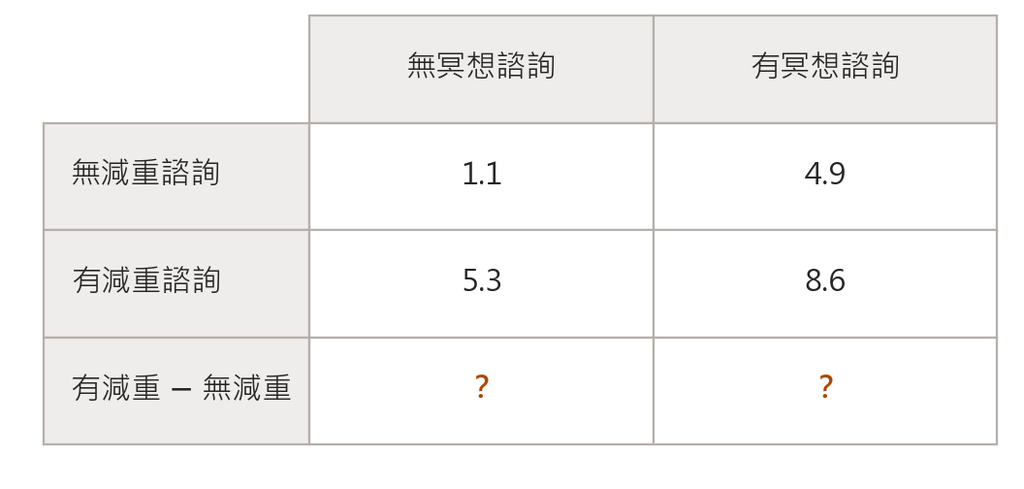

在每一欄內以有減重諮詢減去無減重諮詢。

Rosner 8e Table 12.33；Problem 12.17。差之差由格平均計算。

## 把格平均畫出來

| 組別 | 無冥想 | 有冥想 |
| --- | --- | --- |
| 無減重諮詢 | 1.1 | 4.9 |
| 有減重諮詢 | 5.3 | 8.6 |

兩條線的間距在兩個冥想條件下差不多嗎？先預測，再看**交互作用圖（interaction plot）**。

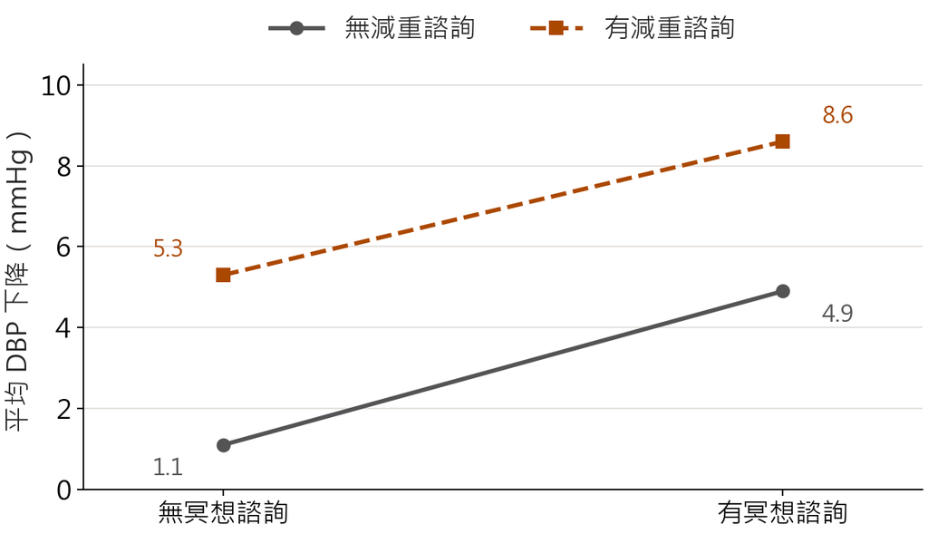

在橫軸的每個冥想條件，分別讀兩條線的高度與線距。

Rosner 8e Table 12.33。依格平均自製圖；是否顯著須看檢定。

## 練習 1｜平均抵消了什麼？

每圖比較三件事。兩個減重邊際平均是否相同？兩個冥想邊際平均是否相同？兩種冥想條件下的減重差是否相同？

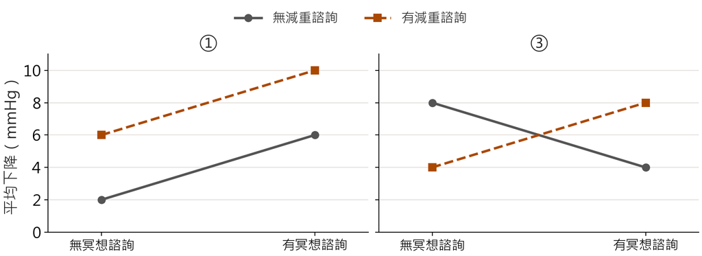

兩圖共用刻度；各格視為等樣本數。只比較樣本平均，不判斷顯著。

| 圖 | 減重邊際有差 | 冥想邊際有差 | 兩種冥想條件的減重差不同 |
| --- | --- | --- | --- |
| ① | 有 | 有 | 否 |
| ③ | 無 | 無 | 是 |

自編練習。格平均為示意值，非 Rosner 資料。

## 練習 1 延伸｜線一定要交叉嗎？

圖②與④的減重邊際、冥想邊際及分條件的減重差各如何？

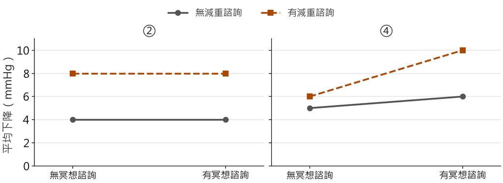

圖④兩線不交叉，仍要比較兩個冥想條件下的線距。

| 圖 | 減重邊際有差 | 冥想邊際有差 | 兩種冥想條件的減重差不同 |
| --- | --- | --- | --- |
| ② | 有 | 無 | 否 |
| ④ | 有 | 有 | 是 |

**樣本中的交互作用看差是否改變，不要求兩線交叉。**

自編延伸練習；不據平均圖判斷統計顯著。

## 總平方和分成格間與格內

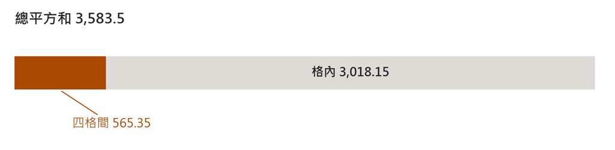

兩段相加是總平方和。橘段來自四個格平均，淺灰段來自每格內的病人。

- **平方和（sum of squares, SS）**衡量偏差的累積。格間比較四個格平均與總平均；格內比較每位病人與自己那格的平均。本例大部分變異在格內。
- 分析採固定效果（fixed effects）模型。各格有相同人數，假定觀察值彼此獨立、各格誤差近似常態且變異數相近。

Rosner 8e §12.6；Table 12.33。由書上四捨五入的平均與 SD 計算，為近似值；拆解圖自製。

## 總平方和怎麼拆？

$A$ 有 $a$ 個水準，$B$ 有 $b$ 個水準，每格 $n$ 筆。$y_{ij\ell}$ 是觀察值，$\bar y_{ij}$ 是格平均，$\bar y$ 是總平均。

依序算總平方和 $SS_T$、格間平方和 $SS_C$、格內平方和 $SS_E$。

$$\begin{aligned}
SS_T &= \sum_{i,j,\ell}(y_{ij\ell}-\bar y)^2 \\
SS_C &= n\sum_{i,j}(\bar y_{ij}-\bar y)^2 \\
SS_E &= \sum_{i,j,\ell}(y_{ij\ell}-\bar y_{ij})^2
\end{aligned}$$

同一格的殘差加總為 0，格間與格內偏差相乘的交叉項因而相消。

$$SS_T=SS_C+SS_E$$

Rosner 8e §12.6；[NIST：雙因子固定效果 ANOVA](https://www.itl.nist.gov/div898/handbook/ppc/section2/ppc232.htm)。

## 只用主要效果，會預測出什麼？

加法預測（additive prediction）用兩個邊際平均。$\bar y_{i\cdot}$ 是第 $i$ 列的平均，$\bar y_{\cdot j}$ 是第 $j$ 欄的平均。

$$\hat y_{ij}=\bar y_{i\cdot}+\bar y_{\cdot j}-\bar y$$

例如，無減重、無冥想的格子，預測值是 $3.00+3.20-4.975=1.225$ mmHg。

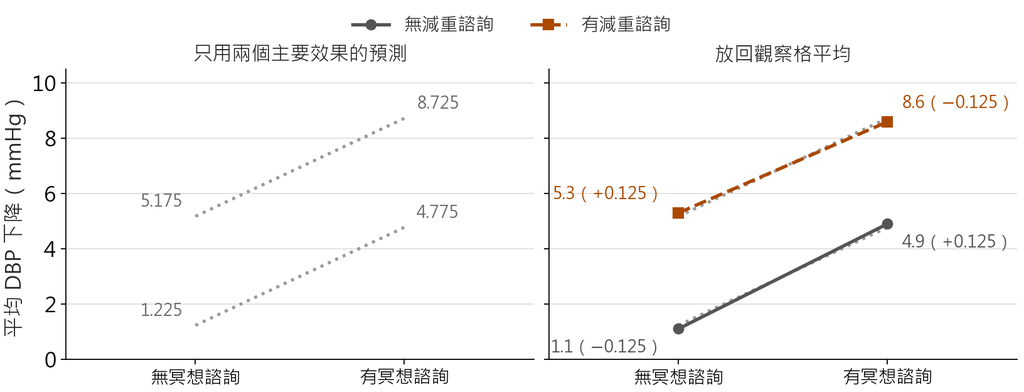

淺灰點線是預測；右圖放回觀察格平均，括號是觀察減預測的偏差。

Rosner 8e Table 12.33。加法預測由格平均計算，自製圖。

## 把格間平方和再拆成三塊

- **減重** $A$：$SS_A=bn\sum_i(\bar y_{i\cdot}-\bar y)^2$
- **冥想** $B$：$SS_B=an\sum_j(\bar y_{\cdot j}-\bar y)^2$
- **交互作用** $AB$：$SS_{AB}=n\sum_{i,j}(\bar y_{ij}-\hat y_{ij})^2$

每個減重邊際平均涵蓋 $bn$ 人，每個冥想邊際平均涵蓋 $an$ 人。交互作用則看每格離加法預測 $\hat y_{ij}$ 有多遠。

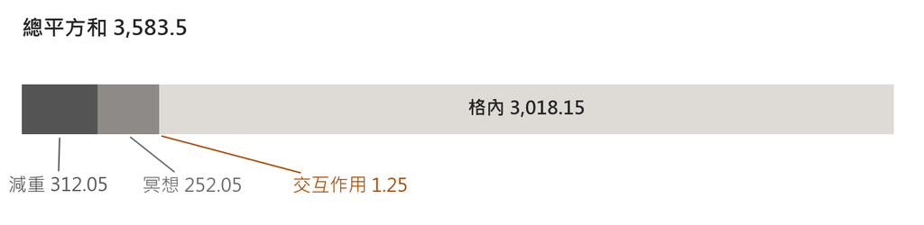

格間平方和由減重、冥想與交互作用組成。

$$SS_C=SS_A+SS_B+SS_{AB}$$

Rosner 8e §12.6、Table 12.33。各格 20 人；平方和依摘要計算，為近似值；自製圖。

## 雙因子 ANOVA 表：從平方和到 F 值

固定效果、每格 $n$ 筆。各列的**均方（mean square, MS）**是該列的平方和除以自由度 $d$。

| 來源 | 自由度 | 平方和 | 均方 | $F$ |
| --- | --- | --- | --- | --- |
| $A$ | $d_A$ | $SS_A$ | $SS_A/d_A$ | $MS_A/MS_E$ |
| $B$ | $d_B$ | $SS_B$ | $SS_B/d_B$ | $MS_B/MS_E$ |
| $A\times B$ | $d_{AB}$ | $SS_{AB}$ | $SS_{AB}/d_{AB}$ | $MS_{AB}/MS_E$ |
| 格內 | $d_E$ | $SS_E$ | $SS_E/d_E$ |  |
| 總計 | $d_T$ | $SS_T$ |  |  |

$d_A=a-1$、$d_B=b-1$、$d_{AB}=(a-1)(b-1)$。

$d_E=ab(n-1)$、$d_T=abn-1$。三個 $F$ 值都用格內均方 $MS_E$ 當分母。

Rosner 8e §12.6；[NIST：雙因子固定效果 ANOVA](https://www.itl.nist.gov/div898/handbook/ppc/section2/ppc232.htm)。

## 交互作用的 F 怎麼讀？

| 來源 | 平方和 | 自由度 | 均方 | F | p |
| --- | --- | --- | --- | --- | --- |
| 減重諮詢 | 312.05 | 1 | 312.05 | 7.86 | .006 |
| 冥想諮詢 | 252.05 | 1 | 252.05 | 6.35 | .014 |
| 減重 × 冥想 | 1.25 | 1 | 1.25 | 0.03 | .86 |
| 格內 | 3,018.15 | 76 | 39.71 |  |  |
| 總計 | 3,583.50 | 79 |  |  |  |

交互作用的 0.03 是哪兩個數相除？

$1.25/(3018.15/76)\approx0.031$。在本例的固定效果模型中，三列的 F 都除以格內均方 39.71。兩個主要效果達 .05 顯著水準，交互作用未達。

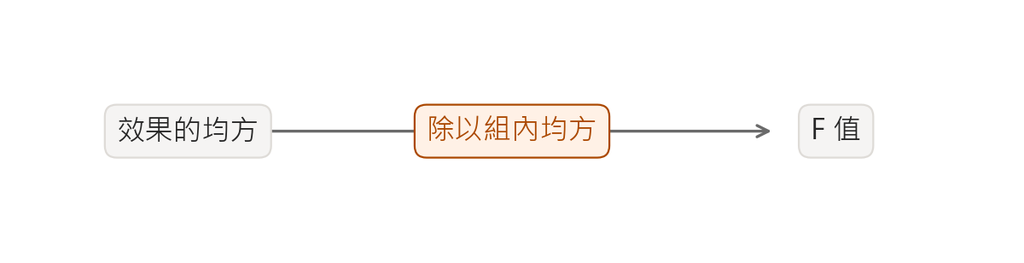

沿箭頭找出 F 的分子與共同分母。

Rosner 8e §12.6；Table 12.33。依四捨五入摘要計算的近似值。

## 交互作用不顯著，平均怎麼讀？

交互作用 $p=.86$。能用「有減重諮詢平均多降 3.95 mmHg」來摘要減重的差嗎？要補哪個提醒？

兩種冥想條件下的樣本差 4.2、3.7 都接近邊際差 3.95，用主要效果摘要是合理的。但 $p=.86$ 只表示資料未顯示差之差，**不能證明**兩個母體差完全相同。

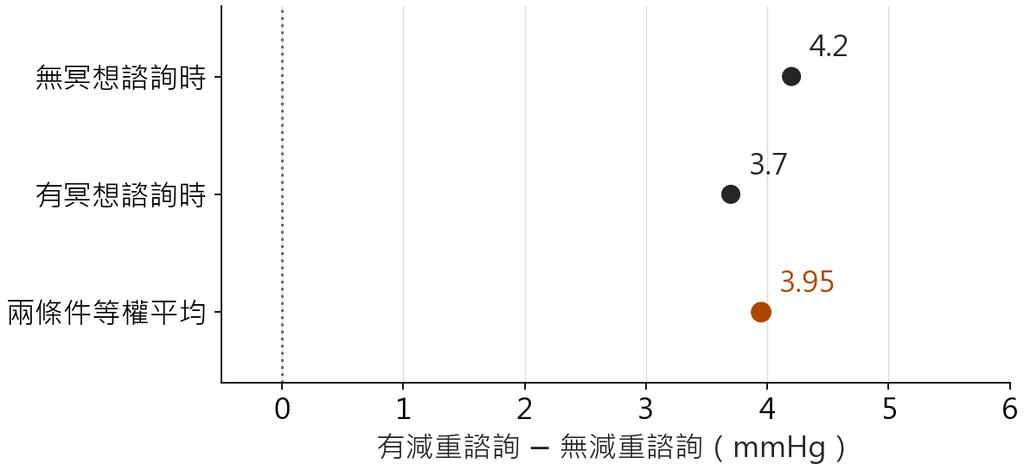

直接比較分條件的減重差與平均後的差。點不是信賴區間。

Rosner 8e Table 12.33；Problems 12.15–12.17。依摘要計算。

## 把檢定句與樣本描述寫清楚

> 未發現交互作用，$F(1,76)=0.03$，$p=.86$。有減重諮詢者平均多降 3.95 mmHg，$F(1,76)=7.86$，$p=.006$；有冥想諮詢者平均多降 3.55 mmHg，$F(1,76)=6.35$，$p=.014$。
- 若事先決定在兩種冥想條件下各比較一次有無減重諮詢，這批有 **2 個比較**。
- 差 3.7、4.2，標準誤 1.99：原始 $p\approx.067$、$.038$。
- Holm 第一關要 $p<.025$，未通過，兩項都不拒絕；校正後 p 皆約 **.077**。
- 主要效果用 40 人對 40 人，各條件內只有 20 對 20；主要效果顯著，不保證各條件內的差顯著。

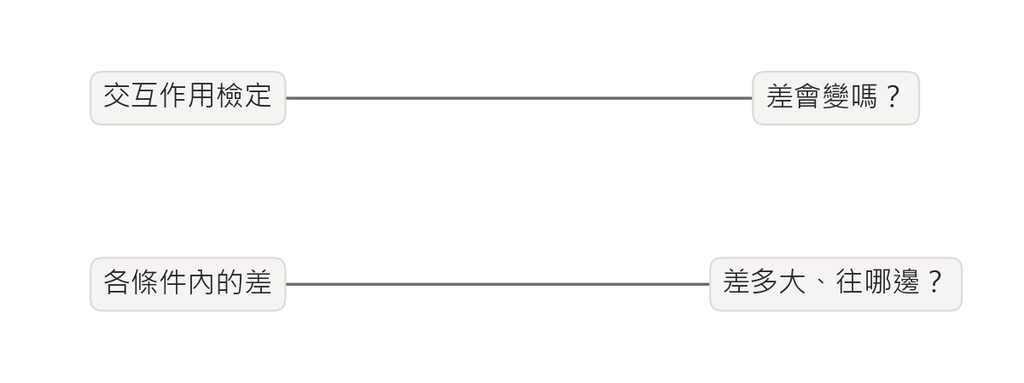

報告時，檢定與條件內的差分別回答不同問題。

Rosner 8e Table 12.33（依摘要近似）；Holm 校正依 R stats `p.adjust`。兩個預定比較依共同格內均方計算。

## 練習 2｜男女差在三種飲食下一樣嗎？

觀察研究：三種飲食型態的成人，依性別記錄平均收縮壓（systolic blood pressure, SBP），單位 mmHg。SV 不吃任何動物產品；LV 是奶素，吃乳製品但不吃其他動物食品；NOR 是一般飲食。括號為人數。

| 飲食型態 | 男 | 女 |
| --- | --- | --- |
| 嚴格素食 SV | 109.9（138） | 102.6（88） |
| 奶素 LV | 115.5（26） | 105.2（37） |
| 一般飲食 NOR | 128.3（240） | 119.6（220） |

算出每種飲食下的男 − 女，並畫出平均線。

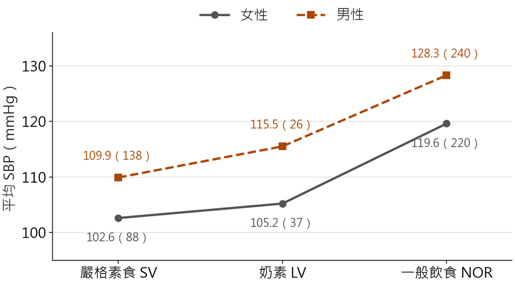

男 − 女依序為 7.3、10.3、8.7 mmHg。

Rosner 8e §12.6，Example 12.23、Table 12.14，pp. 589–590。依格平均自製圖。

## Slido｜Part Three

[figure not shown]

Slido QR code

https://app.sli.do/event/pEcUD1Jb57Wwf9Ujw3bQRH